# 聚类分析

## 一、实验目的

掌握 K-均值、层次聚类算法，理解重要参数对结果的影响。

## 二、实验内容

### 1、k 均值聚类

从 scikit learn 导入 wine 数据集（真实类别为 3），实现 k 均值聚类，输出cluster_label 向量表示聚类结果。计算并输出 NMI 值。可以直接调用 sklearn metrics 中的函数 metrics.normalized_mutual_info_score，具体为：from sklearn import metrics NMI_score= metrics.normalized_mutual_info_score(labels_true, labels) print("normalized Mutual Information: %0.3f"% NMI_score)

可参考以下框架实现 k 均值算法：

- 输入： 数据 X， 簇的个数 K, 最大迭代次数 Max_iter, 最小改变量 eps
- 输出：label(代表样本所在簇的 id)

步骤：

- step 1. 初始化：随机选择 K 个样本作为中心点， 设置迭代次数 t=0;
- step 2. 重复以下交叉迭代直到 t> Max_iter 或 改变量 Eps < eps
  - a. 更新 cluster assignment: 对每个样本，计算其到 K 个中心点的距离，把该样本分配到离他最近的中心对应的簇；
  - b.更新中心点：保存旧的 K 个中心点；对每个簇 c，计算属于该簇的样本的均值作为其新的中心点。计算旧的中心点$\delta_c^t$和新的中心点$\delta_c^{t+1}$的改变量$Eps_c=||\delta_c^t-\delta_c^{t+1}||$ $$t=t+1;Epx=max_c(Eps_c)K个中心点改变量的最大值$$

```python
from sklearn.datasets import load_wine
from sklearn.cluster import KMeans
from sklearn import metrics

# 导入 wine 数据集并划分输入特征和真实标签
wine = load_wine()
X = wine.data
y_true = wine.target

# 初始化 k 均值算法参数并进行聚类
n_clusters = 3
max_iter = 10000
tol = 0.00000001
k_means = KMeans(n_clusters=n_clusters, max_iter=max_iter, tol=tol, random_state=10)
cluster_labels = k_means.fit_predict(X)

# 计算并输出 NMI 值
NMI_score = metrics.normalized_mutual_info_score(y_true, cluster_labels)
print("normalized Mutual Information: %0.3f" % NMI_score)
```

```
normalized Mutual Information: 0.429
```

### 2、层次聚类

2.1 基于欧式距离，分别以最短距离（single linkage）、平均距离（average linkage）为簇间距离度量对 wine 数据集进行凝聚层次聚类，在簇数目为 3 的情况下比较层次聚类与 k 均值的 NMI。

# 以下为层次聚类调用方法

from sklearn.cluster import AgglomerativeClustering  
from scipy.cluster.hierarchy import dendrogram  
model = AgglomerativeClustering(affinity=’euclidean’, distance_threshold=None, nclusters=3, linkage=’single’)  
model = model.fit(X)  
labels=model.labels

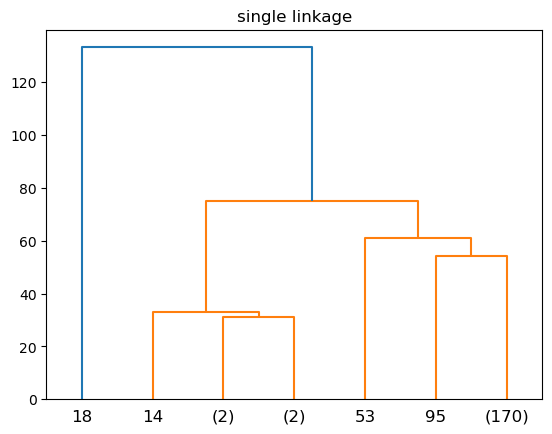

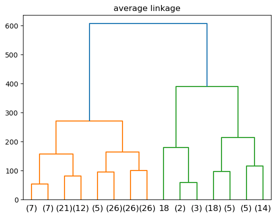

```
single linkage NMI: 0.062
average linkage NMI: 0.405
KMeans NMI: 0.429
```

```python
from sklearn.datasets import load_wine
from sklearn.cluster import KMeans, AgglomerativeClustering
from scipy.cluster.hierarchy import dendrogram, linkage
from sklearn import metrics
import matplotlib.pyplot as plt

# 导入 wine 数据集并划分输入特征和真实标签
wine = load_wine()
X = wine.data
y_true = wine.target

# 初始化 k 均值算法参数并进行聚类
n_clusters = 3
max_iter = 300
tol = 0.0001
k_means = KMeans(n_clusters=n_clusters, max_iter=max_iter, tol=tol, random_state=42)
cluster_labels_kmeans = k_means.fit_predict(X)

# 定义层次聚类函数和相应参数
linkage_methods = ['single', 'average']
labels_hierarchy = []
NMI_scores = []

for link in linkage_methods:
    # 计算距离矩阵并传递给 dendrogram 函数
    dist_matrix = linkage(X, method=link, metric='euclidean')
    plt.title(f'{link} linkage')
    dendrogram(dist_matrix, truncate_mode='level', p=3)
    plt.show()

    # 初始化层次聚类算法参数并进行聚类
    hierarchical = AgglomerativeClustering(n_clusters=n_clusters, linkage=link, affinity='euclidean')
    cluster_labels_hierarchy = hierarchical.fit_predict(X)
    labels_hierarchy.append(cluster_labels_hierarchy)

    # 计算 NMI 并保存结果
    NMI_score = metrics.normalized_mutual_info_score(y_true, cluster_labels_hierarchy)
    NMI_scores.append(NMI_score)

# 输出 NMI 分数
for i, link in enumerate(linkage_methods):
    print(f'{link} linkage NMI: {NMI_scores[i]:.3f}')

# 输出 k 均值聚类的 NMI 分数
NMI_score_kmeans = metrics.normalized_mutual_info_score(y_true, cluster_labels_kmeans)
print(f'KMeans NMI: {NMI_score_kmeans:.3f}')
```

2.2 计算 manhattan 距离矩阵 D，以预先计算好的距离选项调用凝聚层次聚类，重复 1）中实验，比较与欧式距离的结果。  
model = AgglomerativeClustering(affinity=’precomputed’, distance_threshold=None, n_clusters=3, linkage=’single’)  
model = model.fit(D)

```python
from sklearn.datasets import load_wine
from sklearn.cluster import AgglomerativeClustering
from sklearn.metrics import normalized_mutual_info_score
from scipy.spatial.distance import pdist, squareform

# 导入 wine 数据集并划分输入特征和真实标签
wine = load_wine()
X = wine.data
y_true = wine.target

# 计算 manhattan 距离矩阵并进行聚类
D = squareform(pdist(X, metric='cityblock'))
model = AgglomerativeClustering(affinity='precomputed', distance_threshold=None, n_clusters=3, linkage='single')
cluster_labels = model.fit_predict(D)

# 计算并输出 NMI 值
NMI_score = normalized_mutual_info_score(y_true, cluster_labels)
print("normalized Mutual Information: %0.3f" % NMI_score)
```

```
normalized Mutual Information: 0.020
```

### 3、密度聚类（选做）

3.1 对 2D 数据集 noisy_moons(从外部文件夹导入)，打印散点图（用不同颜色表示不同的类）

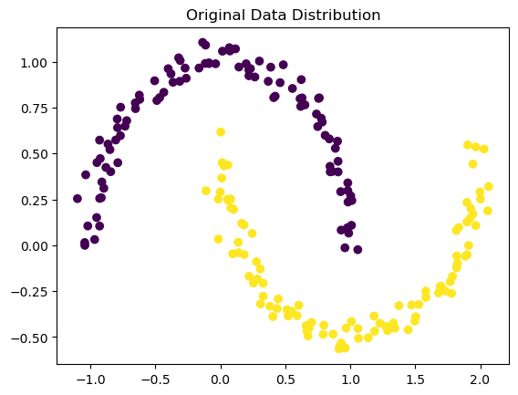

```python
import numpy as np
import matplotlib.pyplot as plt
from sklearn.datasets import make_moons
from sklearn.cluster import DBSCAN

# 生成样本数据
X, y = make_moons(n_samples=200, noise=0.05, random_state=42)

# 绘制散点图显示原始数据分布情况
plt.scatter(X[:, 0], X[:, 1], c=y)
plt.title("Original Data Distribution")
plt.show()
```

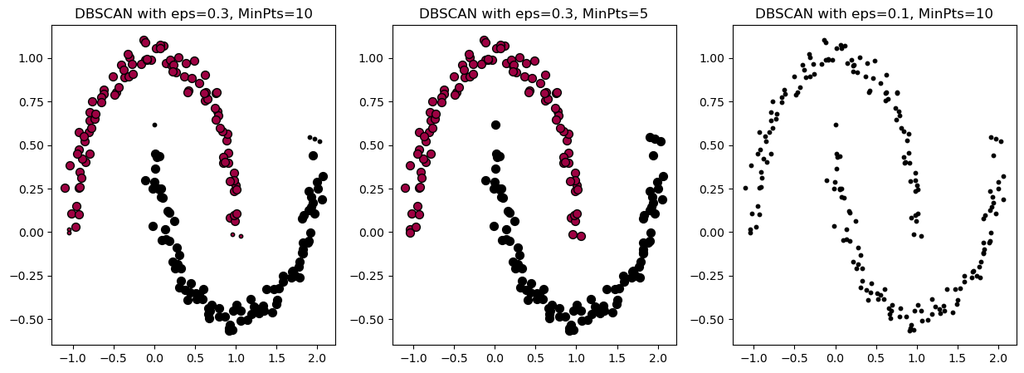

```python
# 使用 DBSCAN 进行聚类，并绘制聚类结果散点图
eps_list = [0.3, 0.3, 0.1]
min_samples_list = [10, 5, 10]

fig, axes = plt.subplots(1, 3, figsize=(15, 5))

for i in range(len(eps_list)):
    eps = eps_list[i]
    min_samples = min_samples_list[i]
    db = DBSCAN(eps=eps, min_samples=min_samples).fit(X)
    core_samples_mask = np.zeros_like(db.labels_, dtype=bool)
    core_samples_mask[db.core_sample_indices_] = True
    labels = db.labels_

    # 将噪声样本标记为黑色
    unique_labels = set(labels)
    colors = [plt.cm.Spectral(each)
              for each in np.linspace(0, 1, len(unique_labels))]
    colors[-1] = (0, 0, 0, 1)

    for k, col in zip(unique_labels, colors):
        if k == -1:
            col = [0, 0, 0, 1]

        class_member_mask = (labels == k)

        xy = X[class_member_mask & core_samples_mask]
        axes[i].scatter(xy[:, 0], xy[:, 1], c=[col], edgecolors='k', s=50)

        xy = X[class_member_mask & ~core_samples_mask]
        axes[i].scatter(xy[:, 0], xy[:, 1], c=[col], edgecolors='k', s=10)

    axes[i].set_title("DBSCAN with eps=%0.1f, MinPts=%d" % (eps, min_samples))

plt.show()
```

## 三、实验总结与讨论

本次实验主要涉及到了 K-均值聚类、层次聚类和密度聚类三种常见的无监督学习算法。其中，K-均值聚类和层次聚类是基于距离度量的聚类算法，而密度聚类则是基于样本密度的聚类算法。